# Titanic Dataset - ML Using Tidymodles

Rohit Ravindra Dusane

2025-04-05

# Machine Leanring with Tidymodels - Tutorials

In this tutorial we will work on the famous `Titanic Dataset` for a classification problem to predict the survival of people. We use the `Tidymodels` framework to build `recipe`, `build model` and `workflow`, testing the accuracy and predict the probabilities of survival.

## 1. Loading Libraries

```r
suppressPackageStartupMessages({
### loading tidyverse/ tidymodels packages
library(tidyverse) #core tidyverse
library(tidymodels) # tidymodels framework
library(lubridate) # date/time handling
library(finetune) # fine tuning models


### visualization
library(viridis) #color scheme that is colorblind friendly
library(ggthemes) # themes for ggplot
library(gt) # to make nice tables
library(cowplot) # to make multi-panel figures
library(corrplot) # nice correlation plot
library(readr) # reading the csv dataset

### Data Cleaning
library(skimr) #provides overview of data and missingness
library(naniar) # handling missing values
library(dplyr) # data handling


### Modeling
library(ranger) # random forest
library(glmnet) # elastic net logistic regression
library(themis) # provides up/down-sampling methods for the data
library(lightgbm) # fast gradient-boosted machine algo
library(bonsai) #provides parnsip objects for tree-based models
library(stacks) # stack ML models for better perfomance
library(vip)
})
```

- The libraries loaded here are used for various tasks such as **data manipulation, cleaning, visualization, and machine learning**.
- `Tidymodels` provides a framework for modeling, `ranger` is used for Random Forest, and other libraries handle different aspects of data processing and visualization.

## 2. Read and View Titanic Data

We will read the `.csv` dataset files from the **Kaggle: Titanic Dataset** (https://www.kaggle.com/c/titanic/overview), a popular dataset in ML community.

```r
df <- read_csv("train.csv", show_col_types = FALSE)

# View data structure
glimpse(df)
```

```
## Rows: 891
## Columns: 12
## $ PassengerId <dbl> 1, 2, 3, 4, 5, 6, 7, 8, 9, 10, 11, 12, 13, 14, 15, 16, 17,…
## $ Survived    <dbl> 0, 1, 1, 1, 0, 0, 0, 0, 1, 1, 1, 1, 0, 0, 0, 1, 0, 1, 0, 1…
## $ Pclass      <dbl> 3, 1, 3, 1, 3, 3, 1, 3, 3, 2, 3, 1, 3, 3, 3, 2, 3, 2, 3, 3…
## $ Name        <chr> "Braund, Mr. Owen Harris", "Cumings, Mrs. John Bradley (Fl…
## $ Sex         <chr> "male", "female", "female", "female", "male", "male", "mal…
## $ Age         <dbl> 22, 38, 26, 35, 35, NA, 54, 2, 27, 14, 4, 58, 20, 39, 14, …
## $ SibSp       <dbl> 1, 1, 0, 1, 0, 0, 0, 3, 0, 1, 1, 0, 0, 1, 0, 0, 4, 0, 1, 0…
## $ Parch       <dbl> 0, 0, 0, 0, 0, 0, 0, 1, 2, 0, 1, 0, 0, 5, 0, 0, 1, 0, 0, 0…
## $ Ticket      <chr> "A/5 21171", "PC 17599", "STON/O2. 3101282", "113803", "37…
## $ Fare        <dbl> 7.2500, 71.2833, 7.9250, 53.1000, 8.0500, 8.4583, 51.8625,…
## $ Cabin       <chr> NA, "C85", NA, "C123", NA, NA, "E46", NA, NA, NA, "G6", "C…
## $ Embarked    <chr> "S", "C", "S", "S", "S", "Q", "S", "S", "S", "C", "S", "S"…
```

## 3. Check for Missing Data

We will check for **missingness** in the data, using `naniar` package.

```r
naniar::miss_var_summary(df)
```

```
## # A tibble: 12 × 3
##    variable    n_miss pct_miss
##    <chr>        <int>    <num>
##  1 Cabin          687   77.1
##  2 Age            177   19.9
##  3 Embarked         2    0.224
##  4 PassengerId      0    0
##  5 Survived         0    0
##  6 Pclass           0    0
##  7 Name             0    0
##  8 Sex              0    0
##  9 SibSp            0    0
## 10 Parch            0    0
## 11 Ticket           0    0
## 12 Fare             0    0
```

**Insights:**

- `miss_var_summary()` is used to quickly summarize the missing values in each column, it helps in understanding the extent of **missingness** in the dataset.
- `Cabin`, `Age` and `Embarked` are having missing values.
- Lets create a function to `clean` the data and `remove` the missing values.
- `Cabin` is dropped since its has a lot of missing values (**`77.1%`**).

### Process (Clean) the TRAINING Data

```r
dataset <- df %>%
  process_data() %>%
  mutate(survived = as_factor(if_else(Survived == 1, "yes", "no"))) %>%
  mutate(survived = relevel(survived, ref = "yes")) %>% # first event is survived = yes
  select(survived, class, gender, age, alone, port, title, fareadjusted, familyage)

# Have a look again
glimpse(dataset)
```

```
## Rows: 891
## Columns: 9
## $ survived     <fct> no, yes, yes, yes, no, no, no, no, yes, yes, yes, yes, no…
## $ class        <fct> third, first, third, first, third, third, first, third, t…
## $ gender       <fct> male, female, female, female, male, male, male, male, fem…
## $ age          <dbl> 22, 38, 26, 35, 35, 30, 54, 2, 27, 14, 4, 58, 20, 39, 14,…
## $ alone        <fct> no, no, yes, no, yes, yes, yes, no, no, no, no, yes, yes,…
## $ port         <fct> 3, 1, 3, 3, 3, 2, 3, 3, 3, 1, 3, 3, 3, 3, 3, 3, 2, 3, 3, …
## $ title        <fct> Mr., Mrs., Miss., Mrs., Mr., Mr., Mr., Master., Mrs., Mrs…
## $ fareadjusted <dbl> 0.008136925, 0.080003704, 0.008894501, 0.059595960, 0.009…
## $ familyage    <dbl> 2.314286, 2.542857, 1.371429, 2.500000, 1.500000, 1.42857…
```

```r
# Check for missing after data preprocessing
naniar::miss_var_summary(dataset)
```

```
## # A tibble: 9 × 3
##   variable     n_miss pct_miss
##   <chr>         <int>    <num>
## 1 survived          0        0
## 2 class             0        0
## 3 gender            0        0
## 4 age               0        0
## 5 alone             0        0
## 6 port              0        0
## 7 title             0        0
## 8 fareadjusted      0        0
## 9 familyage         0        0
```

**Insights:** * The function `process_data()` performs several **data cleaning** tasks on TRAIN dataset. * It creates new variables (like `class`, `alone`, `title`), handles *missing* data for `port` and `age`, and processes features like `fareadjusted` and `familyage`. * The new `dataset` after cleaning is generated. * There are *no missing values* in the data after cleaning.

### Process (Clean) the TESTING Data

```r
test <- read_csv("test.csv", show_col_types = FALSE)
holdout <- test %>%
  process_data() %>%
  select(PassengerId, class, gender, age, alone, port, title, fareadjusted, familyage)

glimpse(holdout)
```

```
## Rows: 418
## Columns: 9
## $ PassengerId  <dbl> 892, 893, 894, 895, 896, 897, 898, 899, 900, 901, 902, 90…
## $ class        <fct> third, third, second, third, third, third, third, second,…
## $ gender       <fct> male, female, male, male, female, male, female, male, fem…
## $ age          <dbl> 34.5, 47.0, 62.0, 27.0, 22.0, 14.0, 30.0, 26.0, 18.0, 21.…
## $ alone        <fct> yes, no, yes, yes, no, yes, yes, no, yes, no, yes, yes, n…
## $ port         <fct> 2, 3, 2, 3, 3, 3, 2, 3, 1, 3, 3, 3, 3, 3, 3, 1, 2, 1, 3, …
## $ title        <fct> Mr., Mrs., Mr., Mr., Mrs., Mr., Miss., Mr., Mrs., Mr., Mr…
## $ fareadjusted <dbl> 0.018730144, 0.016746411, 0.023175837, 0.020723684, 0.029…
## $ familyage    <dbl> 1.492857, 2.671429, 1.885714, 1.385714, 3.314286, 1.20000…
```

```r
# Checking missing in test data
naniar::miss_var_summary(holdout)
```

```
## # A tibble: 9 × 3
##   variable     n_miss pct_miss
##   <chr>         <int>    <num>
## 1 fareadjusted      1    0.239
## 2 PassengerId       0    0
## 3 class             0    0
## 4 gender            0    0
## 5 age               0    0
## 6 alone             0    0
## 7 port              0    0
## 8 title             0    0
## 9 familyage         0    0
```

**Insights:** * The function `process_data()` performs several data cleaning tasks on **TEST** dataset. * Check for missing values in the data (since only 1 case is missing)

## 4. Exploratory data analysis (EDA)

```r
# Train Data
skimr::skim(dataset)
```

Data summary

| Name | dataset |
| --- | --- |
| Number of rows | 891 |
| Number of columns | 9 |
| _______________________ |  |
| Column type frequency: |  |
| factor | 6 |
| numeric | 3 |
| ________________________ |  |
| Group variables | None |

**Variable type: factor**

| skim_variable | n_missing | complete_rate | ordered | n_unique | top_counts |
| --- | --- | --- | --- | --- | --- |
| survived | 0 | 1 | FALSE | 2 | no: 549, yes: 342 |
| class | 0 | 1 | FALSE | 3 | thi: 491, fir: 216, sec: 184 |
| gender | 0 | 1 | FALSE | 2 | mal: 577, fem: 314 |
| alone | 0 | 1 | FALSE | 2 | yes: 537, no: 354 |
| port | 0 | 1 | FALSE | 4 | 3: 644, 1: 168, 2: 77, S: 2 |
| title | 0 | 1 | FALSE | 5 | Mr.: 517, Mis: 182, Mrs: 125, Mas: 40 |

**Variable type: numeric**

| skim_variable | n_missing | complete_rate | mean | sd | p0 | p25 | p50 | p75 | p100 | hist |
| --- | --- | --- | --- | --- | --- | --- | --- | --- | --- | --- |
| age | 0 | 1 | 29.39 | 13.26 | 0.42 | 21.00 | 30.00 | 35.00 | 80.00 | ▂▇▃▁▁ |
| fareadjusted | 0 | 1 | 0.04 | 0.06 | 0.00 | 0.01 | 0.02 | 0.03 | 0.58 | ▇▁▁▁▁ |
| familyage | 0 | 1 | 2.32 | 1.57 | 1.07 | 1.41 | 1.57 | 2.62 | 11.43 | ▇▁▁▁▁ |

** `skim` ** allows to explore the structure of the `TRAIN` dataset.

### Sumarise the data

Explore the data with summaries and plots to view the distribution or patterns in the data.

```r
# Survived
dataset |>
  group_by(survived) |>
  summarise(n = n(),
            n_pct = n / nrow(dataset)*100)
```

```
## # A tibble: 2 × 3
##   survived     n n_pct
##   <fct>    <int> <dbl>
## 1 yes        342  38.4
## 2 no         549  61.6
```

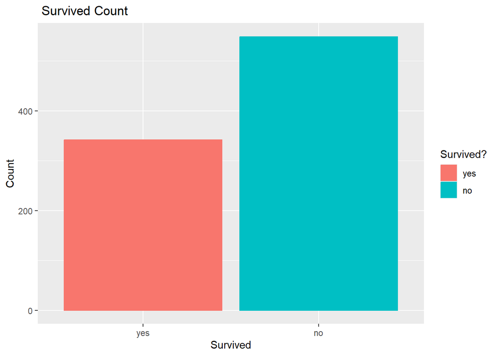

```r
dataset %>%
  ggplot(aes(survived, color = survived, fill = survived)) +
  geom_bar() +
  labs(x = "Survived", y = "Count", color = "Survived?", fill = "Survived?") +
  ggtitle(" Survived Count")
```

```r
# Survived by Gender
dataset |>
  group_by(gender) |>
  summarize(n = n(),
            n_surv = sum(survived == "yes"),
            pct_surv = n_surv / n)
```

```
## # A tibble: 2 × 4
##   gender     n n_surv pct_surv
##   <fct>  <int>  <int>    <dbl>
## 1 female   314    233    0.742
## 2 male     577    109    0.189
```

```r
# Survived by Title
dataset %>%
  group_by(title) %>%
  summarize(n = n(),
            n_surv = sum(survived == "yes"),
            pct_surv = n_surv / n) %>%
  arrange(desc(pct_surv))
```

```
## # A tibble: 5 × 4
##   title       n n_surv pct_surv
##   <fct>   <int>  <int>    <dbl>
## 1 Mrs.      125     99    0.792
## 2 Miss.     182    127    0.698
## 3 Master.    40     23    0.575
## 4 Other      27     12    0.444
## 5 Mr.       517     81    0.157
```

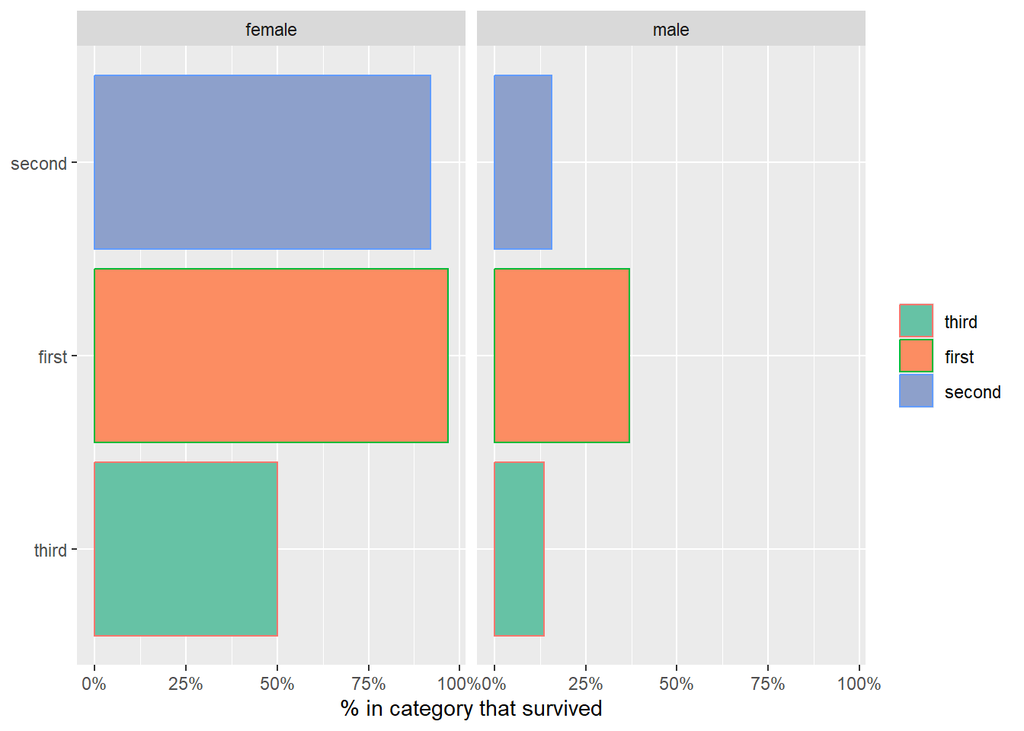

```r
# Summary by class, gender on Survived
dataset %>%
  group_by(class, gender) %>%
  summarize(n = n(),
            n_surv = sum(survived == "yes"),
            pct_surv = n_surv / n) %>%
  mutate(class = fct_reorder(class, pct_surv)) %>%
  ggplot(aes(pct_surv, class, fill = class, color = class)) +
  geom_col(position = position_dodge()) +
  scale_x_continuous(labels = percent) +
  scale_fill_brewer(palette = "Set2") +
  labs(x = "% in category that survived", fill = NULL, color = NULL, y = NULL) +
  facet_wrap(~gender)
```

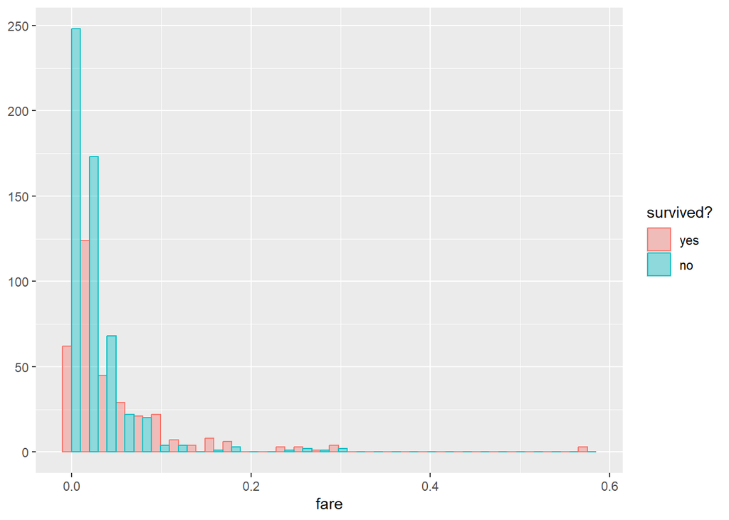

```r
# Fareadjusted Distribution
dataset %>%
  ggplot(aes(fareadjusted, group = survived, color = survived, fill = survived)) +
  geom_histogram(alpha = .4, position = position_dodge()) +
  labs(x = "fare", y = NULL, color = "survived?", fill = "survived?")
```

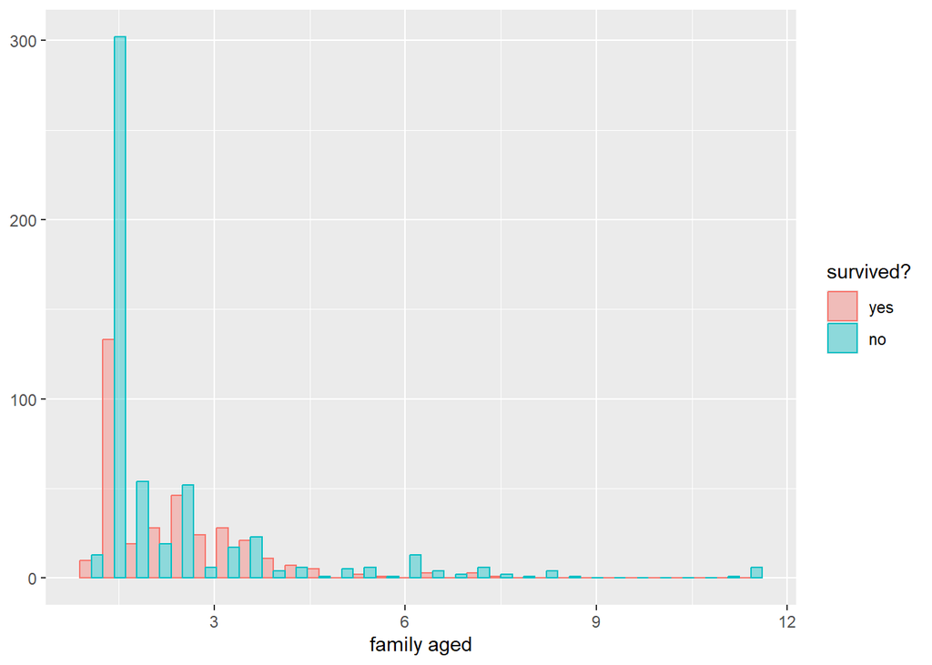

```r
# Familyage Distribution
dataset %>%
  ggplot(aes(familyage, group = survived, color = survived, fill = survived)) +
  geom_histogram(alpha = .4, position = position_dodge()) +
  labs(x = "family aged", y = NULL, color = "survived?", fill = "survived?")
```

## 5. Spliting the Data

In machine learning, it’s crucial to split the dataset into training and testing sets to evaluate model performance effectively.

**Training Set:** This subset of the data is used to train the model, allowing it to learn patterns and relationships within the features (independent variables) and the target (dependent variable).

**Testing Set:** After training the model, we evaluate its performance on the testing dataset. This set is not seen by the model during training, which allows us to assess how well the model generalizes to unseen data.

**Stratification** ensures that the distribution of the target variable in both the training and testing sets is representative of the entire dataset. This is particularly useful when the target variable is imbalanced.

**Cross-Validation (CV)** In *k-fold cross-validation*, the training data is split into k (in this case, 5) equally-sized parts (folds). The model is trained on k-1 folds and tested on the remaining fold, and this process is repeated for each fold.  
Provides a more robust evaluation of model performance by training and testing the model on multiple data splits.

```r
set.seed(2021) # for reproducibility
spl <- initial_split(dataset, strata = "survived")
train <- training(spl)
test <- testing(spl)

set.seed(123)
train_5fold <- vfold_cv(train, v = 5, strata = survived)
train_5fold
```

```
## #  5-fold cross-validation using stratification
## # A tibble: 5 × 2
##   splits            id
##   <list>            <chr>
## 1 <split [532/135]> Fold1
## 2 <split [534/133]> Fold2
## 3 <split [534/133]> Fold3
## 4 <split [534/133]> Fold4
## 5 <split [534/133]> Fold5
```

## 6. LOGISTIC REGRESSION

### 6.1 Create a Recipe for Preprocessing

```r
logistic_rec <- recipe(survived ~ ., data = train) %>%
  step_impute_median(all_numeric()) %>%  # Impute missing values with median for numeric variables
  step_dummy(all_nominal_predictors())   # Convert categorical variables into dummy variables
```

### 6.2 Basic Logistic Regression Model (No Regularization)

We’ll first define and train a basic logistic regression model without any regularization.

```r
logistic_model_basic <- logistic_reg(mode = "classification",
                                     engine = "glm")
```

### 6.3 Set Up the Workflow

```r
logistic_wf_basic <- workflow() %>%
  add_model(logistic_model_basic) %>%
  add_recipe(logistic_rec)
```

### 6.4 Train the Model (No Regularization)

Since we have no regularization, there’s no need for hyperparameter tuning.

```r
logistic_fit_basic <- logistic_wf_basic %>%
  fit(data = train)
```

### 6.5 Evaluate Model Performance

#### 6.5.1 Predict and Calculte Accuracy on the Training Data

```r
train_predictions_basic <- predict(logistic_fit_basic, train, type = "class") %>%
  bind_cols(train %>% select(survived))

train_accuracy_basic <- train_predictions_basic %>%
  accuracy(truth = survived, estimate = .pred_class)
```

#### 6.5.2 Predict and Calculte Accuracy on the Testing Data

```r
test_predictions_basic <- predict(logistic_fit_basic, test, type = "class") %>%
  bind_cols(test %>% select(survived))

test_accuracy_basic <- test_predictions_basic %>%
  accuracy(truth = survived, estimate = .pred_class)
```

#### 6.5.3 Print the Test Accuracy for Basic Logistic Regression

```r
train_accuracy_basic
```

```
## # A tibble: 1 × 3
##   .metric  .estimator .estimate
##   <chr>    <chr>          <dbl>
## 1 accuracy binary         0.835
```

```r
test_accuracy_basic
```

```
## # A tibble: 1 × 3
##   .metric  .estimator .estimate
##   <chr>    <chr>          <dbl>
## 1 accuracy binary         0.821
```

#### 6.5.4 Predict and Calculate ROC-AUC on the TRAIN Set

```r
train_probabilities_basic <- predict(logistic_fit_basic, train, type = "prob") %>%
  bind_cols(train %>% select(survived))

train_roc_auc_basic <- train_probabilities_basic %>%
  roc_curve(truth = survived, .pred_yes)
```

#### 6.5.5 Predict and Calculate ROC-AUC on the TEST Set

```r
test_probabilities_basic <- predict(logistic_fit_basic, test, type = "prob") %>%
  bind_cols(test %>% select(survived))

test_roc_auc_basic <- test_probabilities_basic %>%
  roc_curve(truth = survived, .pred_yes)  # Use .pred_yes for the positive class probability
```

```r
train_roc_auc_basic
```

```
## # A tibble: 585 × 3
##     .threshold specificity sensitivity
##          <dbl>       <dbl>       <dbl>
##  1 -Inf            0                 1
##  2    0.000103     0                 1
##  3    0.00137      0.00243           1
##  4    0.00156      0.00487           1
##  5    0.00245      0.00730           1
##  6    0.00637      0.00973           1
##  7    0.00681      0.0122            1
##  8    0.0126       0.0146            1
##  9    0.0132       0.0170            1
## 10    0.0168       0.0195            1
## # ℹ 575 more rows
```

```r
test_roc_auc_basic
```

```
## # A tibble: 211 × 3
##     .threshold specificity sensitivity
##          <dbl>       <dbl>       <dbl>
##  1 -Inf             0                1
##  2    0.000103      0                1
##  3    0.00245       0.0145           1
##  4    0.00277       0.0290           1
##  5    0.0175        0.0362           1
##  6    0.0191        0.0435           1
##  7    0.0238        0.0507           1
##  8    0.0267        0.0580           1
##  9    0.0301        0.0652           1
## 10    0.0323        0.0725           1
## # ℹ 201 more rows
```

### 6.8 Confusion Matrix on Final model

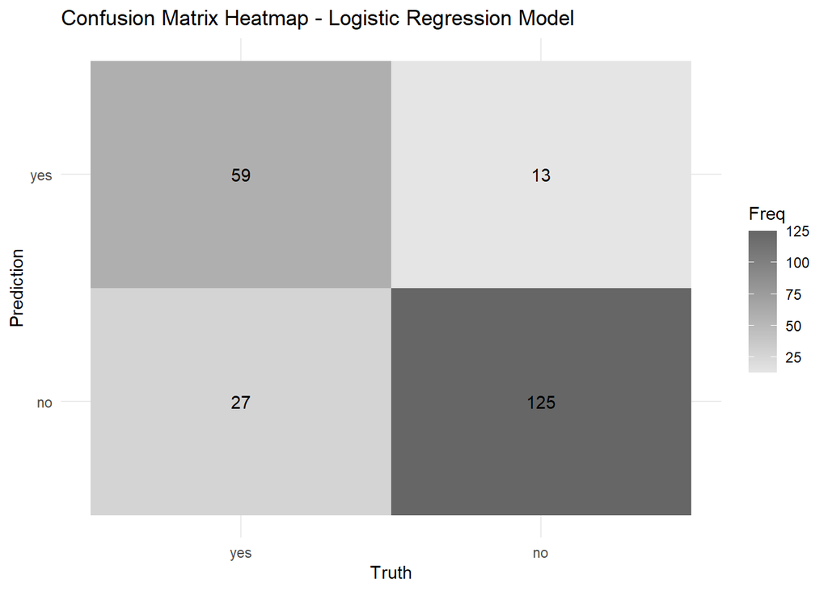

```r
# Create the confusion matrix
conf_matrix_data <- conf_mat(test_predictions_basic,
                             truth = survived,
                             estimate = .pred_class)

# Visualize the confusion matrix as a heatmap
conf_matrix_data %>%
  autoplot(type = "heatmap") +
  ggtitle("Confusion Matrix Heatmap - Logistic Regression Model") +  # Add a title to the plot
  theme_minimal()  # Apply a minimal theme
```

### 7. Random forests

**Random forests** or random decision forests is an `ensemble` learning method for *classification, regression* and other tasks that works by creating a multitude of decision trees during training. For *classification* tasks, the output of the random forest is the class selected by most trees.

### 7.1 Create a Recipie

```r
rf_rec <- recipe(survived ~ ., data = train) %>%
  step_impute_median(all_numeric()) %>% # replace missing value by median
  step_dummy(all_nominal_predictors()) # all factors var are split into binary terms
```

### 7.2 Specify a random forest model.

```r
## Define the RF Model
rf_model <- rand_forest(mode = "classification", # binary response
                        engine = "ranger", # by default
                        mtry = tune(),
                        trees = tune(),
                        min_n = tune()) # parameters to be tuned
```

### 7.3 Set Up the RF workflow.

```r
rf_wf <-
  workflow() %>%
  add_model(rf_model) %>%
  add_recipe(rf_rec)
```

### 7.4 Use cross-validation to evaluate our model with different param config.

```r
# Perform tuning using race anova
rf_tune <- rf_wf %>%
  tune_race_anova(
    train_5fold,  # Your cross-validation splits
    grid = 50,    # Grid size
    param_info = rf_model %>%
    parameters(),  # Hyperparameters to tune
    metrics = metric_set(accuracy, roc_auc),  # Performance metric
    control = control_race(verbose_elim = TRUE)  # Control parameters
  )
```

```
## ℹ Evaluating against the initial 3 burn-in resamples.
```

```
## ℹ Racing will maximize the accuracy metric.
## ℹ Resamples are analyzed in a random order.
## ℹ Fold4: 16 eliminated; 34 candidates remain.
##
## ℹ Fold5: 8 eliminated; 26 candidates remain.
```

### 7.5 Visualize the results.

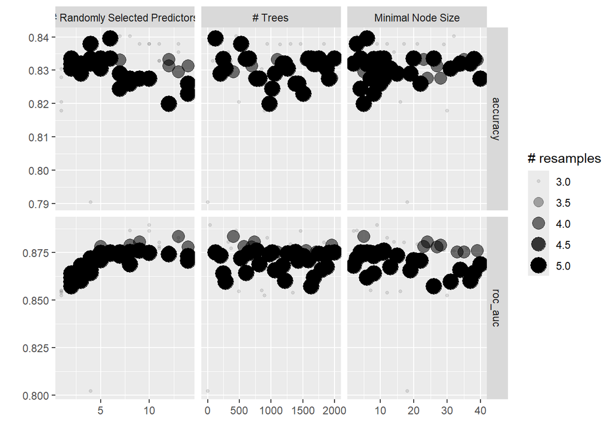

```r
autoplot(rf_tune)
```

### 7.6 Examine the Final Tuned Hyperparameters

```r
best_rf_tune_acc <- rf_tune %>%
  show_best(metric = "accuracy", n=1)  # Or "roc_auc" if you want to use AUC
best_rf_tune_acc
```

```
## # A tibble: 1 × 9
##    mtry trees min_n .metric  .estimator  mean     n std_err .config
##   <int> <int> <int> <chr>    <chr>      <dbl> <int>   <dbl> <chr>
## 1     6   123     6 accuracy binary     0.839     5  0.0142 Preprocessor1_Model…
```

```r
best_rf_tune_roc <- rf_tune %>%
  show_best(metric = "roc_auc", n=1)  # Or "roc_auc" if you want to use AUC
best_rf_tune_roc
```

```
## # A tibble: 1 × 9
##    mtry trees min_n .metric .estimator  mean     n std_err .config
##   <int> <int> <int> <chr>   <chr>      <dbl> <int>   <dbl> <chr>
## 1     9   776    11 roc_auc binary     0.876     5  0.0152 Preprocessor1_Model33
```

### 7.7 Build the model using the best hyperparmetes

Use the `best hyperparameters` to define the **final model**, and then fit it on the entire training dataset.  
Finalize the model using the best hyperparameters

```r
rf_final_model <- rand_forest(
  trees = best_rf_tune_acc$trees[1],  # Best number of trees
  mtry = best_rf_tune_acc$mtry[1]   # Best mtry value
) %>%
  set_engine("ranger", importance = "permutation") %>%
  set_mode("classification")
rf_final_model
```

```
## Random Forest Model Specification (classification)
##
## Main Arguments:
##   mtry = best_rf_tune_acc$mtry[1]
##   trees = best_rf_tune_acc$trees[1]
##
## Engine-Specific Arguments:
##   importance = permutation
##
## Computational engine: ranger
```

```r
# Train the final model on the full training data
final_rf_fit <- rf_final_model %>%
  fit(survived ~ ., data = train)
final_rf_fit
```

```
## parsnip model object
##
## Ranger result
##
## Call:
##  ranger::ranger(x = maybe_data_frame(x), y = y, mtry = min_cols(~best_rf_tune_acc$mtry[1],      x), num.trees = ~best_rf_tune_acc$trees[1], importance = ~"permutation",      num.threads = 1, verbose = FALSE, seed = sample.int(10^5,          1), probability = TRUE)
##
## Type:                             Probability estimation
## Number of trees:                  123
## Sample size:                      667
## Number of independent variables:  8
## Mtry:                             6
## Target node size:                 10
## Variable importance mode:         permutation
## Splitrule:                        gini
## OOB prediction error (Brier s.):  0.1285626
```

### 7.9 Evaluate Model Performance

#### 7.9.1 Predict and Calculate Accuracy on Training data

```r
train_predictions_rf_acc <- predict(final_rf_fit, train, type = "class") %>%
  bind_cols(train %>% select(survived))  # Add the true labels back

train_accuracy_rf_acc <- train_predictions_rf_acc %>%
  accuracy(truth = survived, estimate = .pred_class)
```

#### 7.9.2 Predict and Calculate Accuracy on testing data

```r
test_predictions_rf_acc <- predict(final_rf_fit, test, type = "class") %>%
  bind_cols(test %>% select(survived))  # Add the true labels back

test_accuracy_rf_acc <- test_predictions_rf_acc %>%
  accuracy(truth = survived, estimate = .pred_class)
```

#### 7.9.3 Print the Accuracy

```r
train_accuracy_rf_acc
```

```
## # A tibble: 1 × 3
##   .metric  .estimator .estimate
##   <chr>    <chr>          <dbl>
## 1 accuracy binary         0.937
```

```r
test_accuracy_rf_acc
```

```
## # A tibble: 1 × 3
##   .metric  .estimator .estimate
##   <chr>    <chr>          <dbl>
## 1 accuracy binary         0.826
```

#### 7.9.4 Predict and Calculate ROC-AUC on Training data

```r
train_probabilities_rf_roc <- predict(final_rf_fit, train, type = "prob") %>%
  bind_cols(train %>% select(survived))  # Add the true labels back

train_roc_auc_rf_roc <- train_probabilities_rf_roc %>%
  roc_curve(truth = survived, .pred_yes)  # Use .pred_yes for the positive class probability
```

#### 7.9.5 Predict and Calculate ROC-AUC on Testing data

```r
test_probabilities_rf_roc <- predict(final_rf_fit, test, type = "prob") %>%
  bind_cols(test %>% select(survived))  # Add the true labels back

test_roc_auc_rf_roc <- test_probabilities_rf_roc %>%
  roc_curve(truth = survived, .pred_yes)  # Use .pred_yes for the positive class probability
```

```r
head(train_roc_auc_rf_roc)
```

```
## # A tibble: 6 × 3
##    .threshold specificity sensitivity
##         <dbl>       <dbl>       <dbl>
## 1 -Inf            0                 1
## 2    0            0                 1
## 3    0.000542     0.00243           1
## 4    0.000903     0.0341            1
## 5    0.00136      0.0414            1
## 6    0.00163      0.0462            1
```

```r
head(test_roc_auc_rf_roc)
```

```
## # A tibble: 6 × 3
##    .threshold specificity sensitivity
##         <dbl>       <dbl>       <dbl>
## 1 -Inf            0             1
## 2    0            0             1
## 3    0.000542     0.00725       0.988
## 4    0.000903     0.0145        0.988
## 5    0.00373      0.0217        0.988
## 6    0.00407      0.0290        0.977
```

### 7.11 Confusion Matrix on Final model

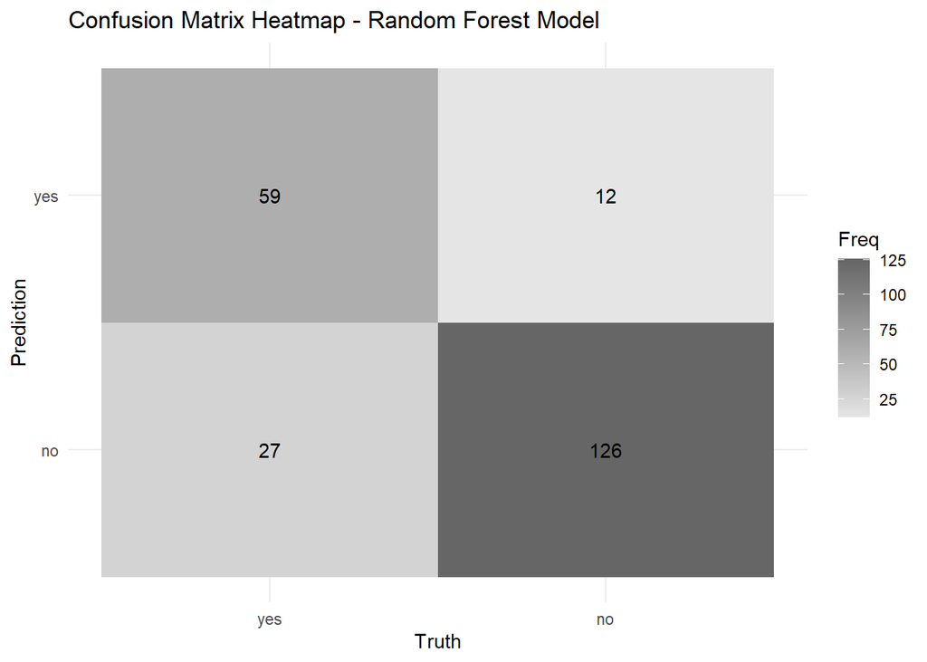

```r
# Create the confusion matrix
conf_matrix_data <- conf_mat(test_predictions_rf_acc,
                             truth = survived,
                             estimate = .pred_class)

# Visualize the confusion matrix as a heatmap
conf_matrix_data %>%
  autoplot(type = "heatmap") +
  ggtitle("Confusion Matrix Heatmap - Random Forest Model") +  # Add a title to the plot
  theme_minimal()  # Apply a minimal theme
```